# Exam_One_A

Conduct a permutation test to determine whether there is a difference in the mean calorie content between ales and lagers. Your test should start with a statement of the formal hypotheses and finish with a conclusion.

The formal statement of the hypotheses is:
$$H_0: \mu_{\text{ale calories}}-\mu_{\text{lager calories}}=0$$

$$H_A: \mu_{\text{ale calories}}-\mu_{\text{lager calories}} \neq 0$$

In particular we are going to compute the difference of means.

```r
library(resampledata)
BeerData<-Alelager
```

First, we’ll extract calorie data for the Ales and for the Lagers:

```r
Ales <- subset(BeerData, select=Calories, subset=Type=="Ale", drop=T)
Lagers <- subset(BeerData, select=Calories, subset=Type=="Lager", drop=T)
```

The observed statistic is:

```r
observed <- mean(Ales)-mean(Lagers)
observed
```

```
## [1] 14.21368
```

We’ll need the following counts in the permutation process:

```r
poolsize <- length(BeerData$Calories)
poolsize
```

```
## [1] 31
```

```r
group1size <- length(Ales)
group1size
```

```
## [1] 13
```

The next chunk computes the permutation distribution. In each iteration of the loop we compute a different difference of means.

```r
N <- 10^4-1
result <- numeric(N)
for (i in 1:N)
{index <- sample(poolsize, group1size, replace=F)
  result[i] <- mean(BeerData$Calories[index])-mean(BeerData$Calories[-index]) }
```

The following histogram isn’t really needed for the test, but it can serve as a red flag is something is wrong.

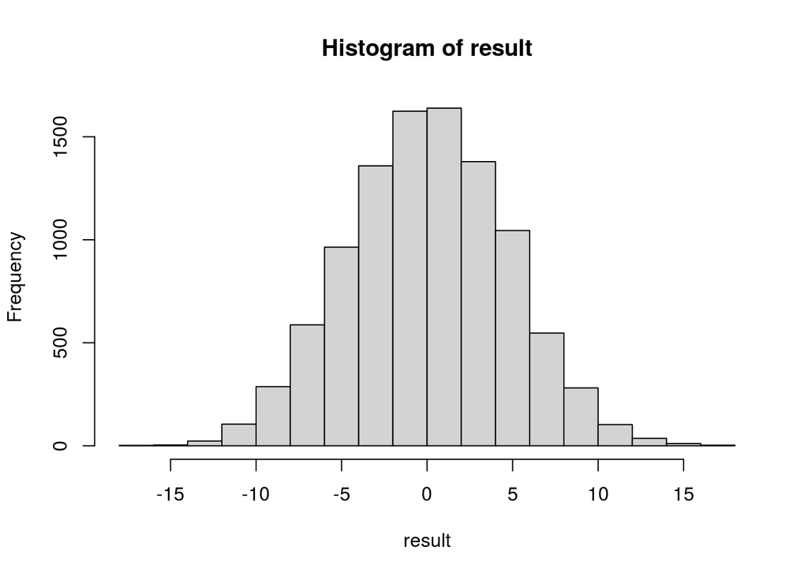

```r
hist(result)
```

Finally, we’ll compute a $p$-value:

```r
2*min((sum(result >= observed)+1)/(N+1),
(sum(result <= observed)+1)/(N+1))
```

```
## [1] 0.0024
```

which is small enough to reject the null hypothesis and conclude there is a mean difference in calories between ales and lagers.

# Critical reading

Below, I conduct a permutation test to test whether there was, on average, a difference in the annual snow fall in Colorado in the years 2019 and 2020. Identify the mistake and fix it.

First, we load and briefly inspect the data:

```r
SnowData <- read.csv("https://www.dropbox.com/s/h8lkjdqoqui3bzw/TestDownload2.csv?dl=1")
head(SnowData)
```

```
##                           StationName Snow2020 Snow2019
## 1               BAYFIELD 6.2 N, CO US     55.3    182.1
## 2 BLACK CANYON OF THE GUNNISON, CO US    103.9    165.0
## 3           BLACK FOREST 3.8 W, CO US    110.4    184.6
## 4           BLACK FOREST 6 WNW, CO US     73.9    125.3
## 5                BOULDER 1.6 S, CO US    124.4    124.8
## 6                BOULDER 2.9 S, CO US    113.9    116.0
```

The data shows annual snow fall recorded at 51 NOAA weather station in Colorado in 2019 and 2020.

The formal statements of the hypotheses are:

$$H_0: \mu_{d_{2020}-d_{2019}}=0$$

$$H_A: \mu_{d_{2020}-d_{2019}}\neq 0$$

where $d_{2019}$ and $d_{2020}$ are the number of inches of snowfall at a particular station in 2019 and 2020 respectively.

We’ll compute the difference in snowfall at each station and compute the observed mean of differences:

```r
DiffAtStations<-SnowData$Snow2020-SnowData$Snow2019
Observed<-mean(DiffAtStations)
Observed
```

```
## [1] -25.45098
```

Next, we’ll pool the data in order to find a permutation distribution:

This is the first hint that something is wrong. It doesn’t make sense to pool all this data. The stations are in widely different areas of Colorado and so we need to keep the data matched by stations. We will conduct a matched pairs test. I will comment out all the lines that don’t belong.

```r
#PooledData<- c(SnowData$Snow2020, SnowData$Snow2019)
```

Here is the loop that generates a sampling distribution (a permutation distribution in this case);

```r
#N=10^4
#SampleDist<-numeric(N)
#for (i in 1:N)
#{index<-sample(102,51, replace=F)
#SampleDist[i]<- mean(PooledData[index]-PooledData[-index])}
```

Finally, we compute the $p$-value for our observed statistic:

```r
#2*min((sum(SampleDist >= Observed)+1)/(N+1),
#(sum(SampleDist <= Observed)+1)/(N+1))
```

Since the $p$-value is small we reject the null hypothesis and conclude that the mean difference in snow depth between 2019 and 2020 was different.

Below is the matched pairs permutation test. Instead of pooling the data, we swap measurements for the *same* station at random. The two lines in the for loop do this.

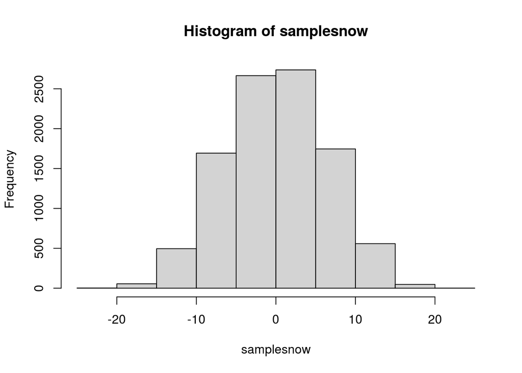

```r
N=10^4-1
samplesnow <- numeric(N)
DiffInSnow <- SnowData$Snow2020-SnowData$Snow2019
observedsnow <- mean(DiffInSnow)


for (i in 1:N)
{Sgn <- sample(c(-1,1), 51, replace=T)
samplesnow[i] <- mean(Sgn*DiffInSnow)}

hist(samplesnow)
```

We compute a $p$-value:

```r
2*min((sum(samplesnow >= observedsnow)+1)/(N+1),
(sum(samplesnow <= observedsnow)+1)/(N+1))
```

```
## [1] 2e-04
```

which is small enough to reject the null hypothesis. We conclude that there was a mean difference in snow fall between 2019 and 2020.